# cyclistic

**Company name : Cyclistic (fictional)**

*Type of company : Bike-share company*

Context : *In 2016, Cyclistic launched a successful bike-share offering. Since then, the program has grown to a fleet of 5,824 bicycles that are geotracked and locked into a network of 692 stations across Chicago. The bikes can be unlocked from one station and returned to any other station in the system anytime.*

**How do annual members and casual riders use Cyclistic bikes differently?**

```python
import os
import pandas as pd
import numpy as np
import matplotlib.pyplot as plt
```

### *Combine files*

Folder have 12 csv files.

These files have data of 2023.

Combine files to analyse 12 months data.

```python
# files = [file for file in os.listdir('./csv_files_202301_202312')]

# all_months_data = pd.DataFrame()

# for file in files:
#     current_data = pd.read_csv('./csv_files_202301_202312/'+file)
#     all_months_data = pd.concat([all_months_data, current_data])

# all_months_data.to_csv('2023tripdata.csv')
```

```python
all_months_data = pd.read_csv('2023tripdata.csv', index_col=0)
```

### **Gather information about data**

```python
all_months_data.info()
```

```
<class 'pandas.core.frame.DataFrame'>
Index: 5719877 entries, 0 to 224072
Data columns (total 13 columns):
 #   Column              Dtype
---  ------              -----
 0   ride_id             object
 1   rideable_type       object
 2   started_at          object
 3   ended_at            object
 4   start_station_name  object
 5   start_station_id    object
 6   end_station_name    object
 7   end_station_id      object
 8   start_lat           float64
 9   start_lng           float64
 10  end_lat             float64
 11  end_lng             float64
 12  member_casual       object
dtypes: float64(4), object(9)
memory usage: 610.9+ MB
```

```python
all_months_data.head()
```

|  | ride_id | rideable_type | started_at | ended_at | start_station_name | start_station_id | end_station_name | end_station_id | start_lat | start_lng | end_lat | end_lng | member_casual |
| --- | --- | --- | --- | --- | --- | --- | --- | --- | --- | --- | --- | --- | --- |
| 0 | F96D5A74A3E41399 | electric_bike | 2023-01-21 20:05:42 | 2023-01-21 20:16:33 | Lincoln Ave & Fullerton Ave | TA1309000058 | Hampden Ct & Diversey Ave | 202480.0 | 41.924074 | -87.646278 | 41.930000 | -87.640000 | member |
| 1 | 13CB7EB698CEDB88 | classic_bike | 2023-01-10 15:37:36 | 2023-01-10 15:46:05 | Kimbark Ave & 53rd St | TA1309000037 | Greenwood Ave & 47th St | TA1308000002 | 41.799568 | -87.594747 | 41.809835 | -87.599383 | member |
| 2 | BD88A2E670661CE5 | electric_bike | 2023-01-02 07:51:57 | 2023-01-02 08:05:11 | Western Ave & Lunt Ave | RP-005 | Valli Produce - Evanston Plaza | 599 | 42.008571 | -87.690483 | 42.039742 | -87.699413 | casual |
| 3 | C90792D034FED968 | classic_bike | 2023-01-22 10:52:58 | 2023-01-22 11:01:44 | Kimbark Ave & 53rd St | TA1309000037 | Greenwood Ave & 47th St | TA1308000002 | 41.799568 | -87.594747 | 41.809835 | -87.599383 | member |
| 4 | 3397017529188E8A | classic_bike | 2023-01-12 13:58:01 | 2023-01-12 14:13:20 | Kimbark Ave & 53rd St | TA1309000037 | Greenwood Ave & 47th St | TA1308000002 | 41.799568 | -87.594747 | 41.809835 | -87.599383 | member |

```python
rows, columns = all_months_data.shape
print(f'Rows: {rows}\nColumns: {columns}')
```

```
Rows: 5719877
Columns: 13
```

```python
all_months_data.isnull().sum()
```

```
ride_id                    0
rideable_type              0
started_at                 0
ended_at                   0
start_station_name    875716
start_station_id      875848
end_station_name      929202
end_station_id        929343
start_lat                  0
start_lng                  0
end_lat                 6990
end_lng                 6990
member_casual              0
dtype: int64
```

### **Delete unnecessary columns**

Here we are not going to look at the station data.

```python
all_months_data.drop(['start_station_name','start_station_id','end_station_name','end_station_id'],axis=1, inplace=True)
```

```python
all_months_data.isnull().sum()
```

```
ride_id             0
rideable_type       0
started_at          0
ended_at            0
start_lat           0
start_lng           0
end_lat          6990
end_lng          6990
member_casual       0
dtype: int64
```

```python
all_months_data = all_months_data.rename(columns={'member_casual': 'user_type'})
```

### **Changed datatype**

Column having date is of type object.

Change column type to datetime.

Create new column for the ride length.

```python
all_months_data['started_at'] = pd.to_datetime(all_months_data['started_at'])
all_months_data['ended_at'] = pd.to_datetime(all_months_data['ended_at'])
all_months_data['ride_len'] = all_months_data['ended_at'] - all_months_data['started_at']
all_months_data.info()
```

```
<class 'pandas.core.frame.DataFrame'>
Index: 5719877 entries, 0 to 224072
Data columns (total 10 columns):
 #   Column         Dtype
---  ------         -----
 0   ride_id        object
 1   rideable_type  object
 2   started_at     datetime64[ns]
 3   ended_at       datetime64[ns]
 4   start_lat      float64
 5   start_lng      float64
 6   end_lat        float64
 7   end_lng        float64
 8   user_type      object
 9   ride_len       timedelta64[ns]
dtypes: datetime64[ns](2), float64(4), object(3), timedelta64[ns](1)
memory usage: 480.0+ MB
```

### **Deleting rows**

Delete rows having ride length less than 0 min.

```python
all_months_data['ride_len_min'] = round(all_months_data['ride_len'].dt.total_seconds() / 60).astype('int32')
all_months_data = all_months_data[all_months_data['ride_len_min'] > 0]
all_months_data.head()
```

|  | ride_id | rideable_type | started_at | ended_at | start_lat | start_lng | end_lat | end_lng | user_type | ride_len | ride_len_min |
| --- | --- | --- | --- | --- | --- | --- | --- | --- | --- | --- | --- |
| 0 | F96D5A74A3E41399 | electric_bike | 2023-01-21 20:05:42 | 2023-01-21 20:16:33 | 41.924074 | -87.646278 | 41.930000 | -87.640000 | member | 0 days 00:10:51 | 11 |
| 1 | 13CB7EB698CEDB88 | classic_bike | 2023-01-10 15:37:36 | 2023-01-10 15:46:05 | 41.799568 | -87.594747 | 41.809835 | -87.599383 | member | 0 days 00:08:29 | 8 |
| 2 | BD88A2E670661CE5 | electric_bike | 2023-01-02 07:51:57 | 2023-01-02 08:05:11 | 42.008571 | -87.690483 | 42.039742 | -87.699413 | casual | 0 days 00:13:14 | 13 |
| 3 | C90792D034FED968 | classic_bike | 2023-01-22 10:52:58 | 2023-01-22 11:01:44 | 41.799568 | -87.594747 | 41.809835 | -87.599383 | member | 0 days 00:08:46 | 9 |
| 4 | 3397017529188E8A | classic_bike | 2023-01-12 13:58:01 | 2023-01-12 14:13:20 | 41.799568 | -87.594747 | 41.809835 | -87.599383 | member | 0 days 00:15:19 | 15 |

### **Analyse Data**

Check ride length data for outliers.

```python
all_months_data['ride_len'].describe()
```

```
count                      5621879
mean     0 days 00:18:29.871122270
std      0 days 03:01:45.462095704
min                0 days 00:00:31
25%                0 days 00:05:36
50%                0 days 00:09:42
75%                0 days 00:17:07
max               68 days 09:29:04
Name: ride_len, dtype: object
```

```python
all_months_data[(all_months_data['ride_len'] > '0 days 4:00:00') & (all_months_data['user_type'] == 'member')].count()
```

```
ride_id          4360
rideable_type    4360
started_at       4360
ended_at         4360
start_lat        4360
start_lng        4360
end_lat          3246
end_lng          3246
user_type        4360
ride_len         4360
ride_len_min     4360
dtype: int64
```

```python
all_months_data[(all_months_data['ride_len'] > '0 days 4:00:00') & (all_months_data['user_type'] == 'casual')].count()
```

```
ride_id          11522
rideable_type    11522
started_at       11522
ended_at         11522
start_lat        11522
start_lng        11522
end_lat           6019
end_lng           6019
user_type        11522
ride_len         11522
ride_len_min     11522
dtype: int64
```

```python
all_months_data['rideable_type'].unique()
```

```
array(['electric_bike', 'classic_bike', 'docked_bike'], dtype=object)
```

### **Create Columns**

Create columns for DAY, MONTH, HOUR, DAY NAME

These will be used for analysing rider behaviour

```python
all_months_data['started_at_day'] = all_months_data['started_at'].dt.day
all_months_data['started_at_month'] = all_months_data['started_at'].dt.month
all_months_data['started_at_hour'] = all_months_data['started_at'].dt.hour
all_months_data['started_at_dayname'] = all_months_data['started_at'].dt.day_name()
```

```python
all_months_data.head()
```

|  | ride_id | rideable_type | started_at | ended_at | start_lat | start_lng | end_lat | end_lng | user_type | ride_len | ride_len_min | started_at_day | started_at_month | started_at_hour | started_at_dayname |
| --- | --- | --- | --- | --- | --- | --- | --- | --- | --- | --- | --- | --- | --- | --- | --- |
| 0 | F96D5A74A3E41399 | electric_bike | 2023-01-21 20:05:42 | 2023-01-21 20:16:33 | 41.924074 | -87.646278 | 41.930000 | -87.640000 | member | 0 days 00:10:51 | 11 | 21 | 1 | 20 | Saturday |
| 1 | 13CB7EB698CEDB88 | classic_bike | 2023-01-10 15:37:36 | 2023-01-10 15:46:05 | 41.799568 | -87.594747 | 41.809835 | -87.599383 | member | 0 days 00:08:29 | 8 | 10 | 1 | 15 | Tuesday |
| 2 | BD88A2E670661CE5 | electric_bike | 2023-01-02 07:51:57 | 2023-01-02 08:05:11 | 42.008571 | -87.690483 | 42.039742 | -87.699413 | casual | 0 days 00:13:14 | 13 | 2 | 1 | 7 | Monday |
| 3 | C90792D034FED968 | classic_bike | 2023-01-22 10:52:58 | 2023-01-22 11:01:44 | 41.799568 | -87.594747 | 41.809835 | -87.599383 | member | 0 days 00:08:46 | 9 | 22 | 1 | 10 | Sunday |
| 4 | 3397017529188E8A | classic_bike | 2023-01-12 13:58:01 | 2023-01-12 14:13:20 | 41.799568 | -87.594747 | 41.809835 | -87.599383 | member | 0 days 00:15:19 | 15 | 12 | 1 | 13 | Thursday |

### **Total number of rides per month**

```python
rides_per_month = all_months_data.groupby('started_at_month').count()['ride_id']
rides_per_month
```

```
started_at_month
1     186020
2     186192
3     252247
4     416239
5     592901
6     707260
7     754878
8     760023
9     657215
10    529761
11    357800
12    221343
Name: ride_id, dtype: int64
```

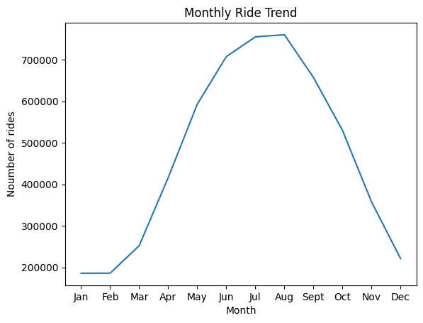

```python
plt.plot(rides_per_month)
plt.xlabel('Month')
plt.xticks(np.arange(1,13), ['Jan', 'Feb', 'Mar', 'Apr', 'May', 'Jun', 'Jul', 'Aug', 'Sept', 'Oct', 'Nov', 'Dec'])
plt.ylabel('Noumber of rides')
plt.title('Monthly Ride Trend')
plt.xticks(np.arange(1,13))
plt.show()
```

### **Total number of rides taken by casual riders and members per month**

```python
rides_per_month_by_member = all_months_data.groupby(['started_at_month','user_type']).count()['ride_id']
rides_per_month_by_member
```

```
started_at_month  user_type
1                 casual        39236
                  member       146784
2                 casual        42204
                  member       143988
3                 casual        60887
                  member       191360
4                 casual       144132
                  member       272107
5                 casual       229817
                  member       363084
6                 casual       295977
                  member       411283
7                 casual       326009
                  member       428869
8                 casual       306580
                  member       453443
9                 casual       257933
                  member       399282
10                casual       174511
                  member       355250
11                casual        97035
                  member       260765
12                casual        51004
                  member       170339
Name: ride_id, dtype: int64
```

```python
rides_per_month_by_member = rides_per_month_by_member.reset_index()
rides_per_month_by_member
```

|  | started_at_month | user_type | ride_id |
| --- | --- | --- | --- |
| 0 | 1 | casual | 39236 |
| 1 | 1 | member | 146784 |
| 2 | 2 | casual | 42204 |
| 3 | 2 | member | 143988 |
| 4 | 3 | casual | 60887 |
| 5 | 3 | member | 191360 |
| 6 | 4 | casual | 144132 |
| 7 | 4 | member | 272107 |
| 8 | 5 | casual | 229817 |
| 9 | 5 | member | 363084 |
| 10 | 6 | casual | 295977 |
| 11 | 6 | member | 411283 |
| 12 | 7 | casual | 326009 |
| 13 | 7 | member | 428869 |
| 14 | 8 | casual | 306580 |
| 15 | 8 | member | 453443 |
| 16 | 9 | casual | 257933 |
| 17 | 9 | member | 399282 |
| 18 | 10 | casual | 174511 |
| 19 | 10 | member | 355250 |
| 20 | 11 | casual | 97035 |
| 21 | 11 | member | 260765 |
| 22 | 12 | casual | 51004 |
| 23 | 12 | member | 170339 |

```python
pivot_table = rides_per_month_by_member.pivot(index='started_at_month', columns='user_type', values='ride_id')
pivot_table
```

| user_type started_at_month | casual | member |
| --- | --- | --- |
| 1 | 39236 | 146784 |
| 2 | 42204 | 143988 |
| 3 | 60887 | 191360 |
| 4 | 144132 | 272107 |
| 5 | 229817 | 363084 |
| 6 | 295977 | 411283 |
| 7 | 326009 | 428869 |
| 8 | 306580 | 453443 |
| 9 | 257933 | 399282 |
| 10 | 174511 | 355250 |
| 11 | 97035 | 260765 |
| 12 | 51004 | 170339 |

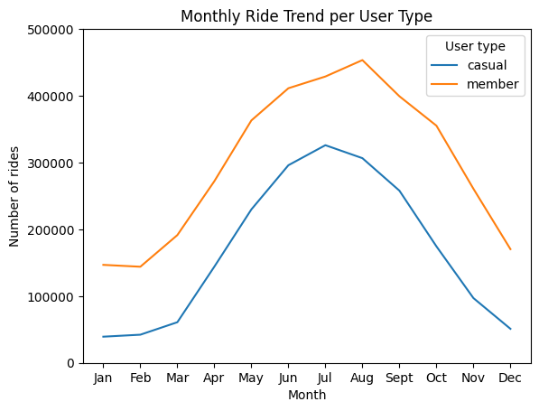

```python
pivot_table.plot(kind='line')
plt.xlabel('Month')
plt.ylabel('Number of rides')
plt.title('Monthly Ride Trend per User Type')
plt.yticks([i for i in range(0,600000,100000)])
plt.xticks(np.arange(1,13), ['Jan', 'Feb', 'Mar', 'Apr', 'May', 'Jun', 'Jul', 'Aug', 'Sept', 'Oct', 'Nov', 'Dec'])
plt.legend(title='User type')
plt.show()
```

### **Making weekday a categorical data to maintain order.**

```python
weekday_order = ['Monday', 'Tuesday', 'Wednesday', 'Thursday', 'Friday', 'Saturday', 'Sunday']
all_months_data['started_at_dayname'] = pd.Categorical(all_months_data['started_at_dayname'], categories=weekday_order, ordered=True)
all_months_data.head()
```

|  | ride_id | rideable_type | started_at | ended_at | start_lat | start_lng | end_lat | end_lng | user_type | ride_len | ride_len_min | started_at_day | started_at_month | started_at_hour | started_at_dayname |
| --- | --- | --- | --- | --- | --- | --- | --- | --- | --- | --- | --- | --- | --- | --- | --- |
| 0 | F96D5A74A3E41399 | electric_bike | 2023-01-21 20:05:42 | 2023-01-21 20:16:33 | 41.924074 | -87.646278 | 41.930000 | -87.640000 | member | 0 days 00:10:51 | 11 | 21 | 1 | 20 | Saturday |
| 1 | 13CB7EB698CEDB88 | classic_bike | 2023-01-10 15:37:36 | 2023-01-10 15:46:05 | 41.799568 | -87.594747 | 41.809835 | -87.599383 | member | 0 days 00:08:29 | 8 | 10 | 1 | 15 | Tuesday |
| 2 | BD88A2E670661CE5 | electric_bike | 2023-01-02 07:51:57 | 2023-01-02 08:05:11 | 42.008571 | -87.690483 | 42.039742 | -87.699413 | casual | 0 days 00:13:14 | 13 | 2 | 1 | 7 | Monday |
| 3 | C90792D034FED968 | classic_bike | 2023-01-22 10:52:58 | 2023-01-22 11:01:44 | 41.799568 | -87.594747 | 41.809835 | -87.599383 | member | 0 days 00:08:46 | 9 | 22 | 1 | 10 | Sunday |
| 4 | 3397017529188E8A | classic_bike | 2023-01-12 13:58:01 | 2023-01-12 14:13:20 | 41.799568 | -87.594747 | 41.809835 | -87.599383 | member | 0 days 00:15:19 | 15 | 12 | 1 | 13 | Thursday |

### **Total number of rides taken by casual and members per weekday**

```python
rides_per_week = all_months_data.groupby(['started_at_dayname','user_type']).count()['ride_id']
rides_per_week = rides_per_week.reset_index()
pivot_table = rides_per_week.pivot(index='started_at_dayname' , columns='user_type' , values='ride_id')
pivot_table
```

| user_type started_at_dayname | casual | member |
| --- | --- | --- |
| Monday | 231014 | 486069 |
| Tuesday | 242212 | 566907 |
| Wednesday | 245031 | 576550 |
| Thursday | 266154 | 579072 |
| Friday | 306744 | 521937 |
| Saturday | 404019 | 464251 |
| Sunday | 330151 | 401768 |

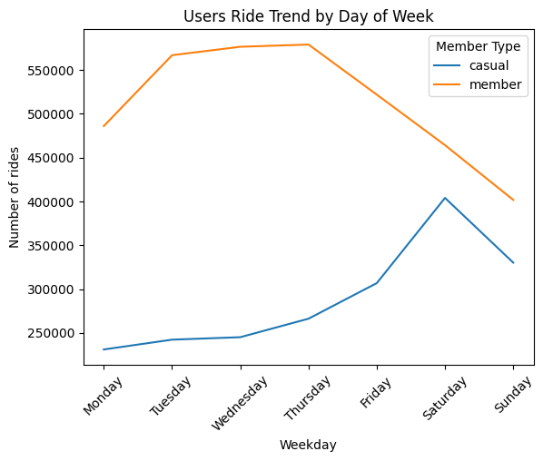

```python
pivot_table.plot(kind='line')
plt.xlabel('Weekday')
plt.ylabel('Number of rides')
plt.title('Users Ride Trend by Day of Week')
plt.legend(title='Member Type')
plt.xticks(rotation=45)
plt.show()
```

### **Total number of rides taken by casual and members using different types of cycle**

```python
bike_vs_member_pivot_table = all_months_data.groupby(['rideable_type', 'user_type']).count()['ride_id'].reset_index().pivot(index='user_type' , columns='rideable_type', values='ride_id').fillna(0)
bike_vs_member_pivot_table
```

| rideable_type user_type | classic_bike | docked_bike | electric_bike |
| --- | --- | --- | --- |
| casual | 869750.0 | 77826.0 | 1077749.0 |
| member | 1800170.0 | 0.0 | 1796384.0 |

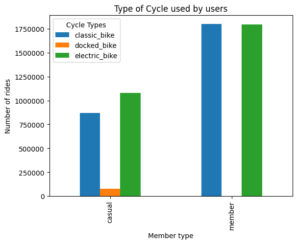

```python
bike_vs_member_pivot_table.plot(kind='bar')
plt.title('Type of Cycle used by users')
plt.xlabel('Member type')
plt.ylabel('Number of rides')
plt.legend(title='Cycle Types')
plt.yticks(np.arange(0,2000000, 250000),[0, 250000, 500000, 750000, 1000000, 1250000, 1500000, 1750000])
plt.show()
```

```python
all_months_data.sample(5)
```

|  | ride_id | rideable_type | started_at | ended_at | start_lat | start_lng | end_lat | end_lng | user_type | ride_len | ride_len_min | started_at_day | started_at_month | started_at_hour | started_at_dayname |
| --- | --- | --- | --- | --- | --- | --- | --- | --- | --- | --- | --- | --- | --- | --- | --- |
| 149382 | 2B7334B5C0C8FA85 | classic_bike | 2023-12-13 17:26:53 | 2023-12-13 17:33:14 | 41.883380 | -87.641170 | 41.870257 | -87.639474 | member | 0 days 00:06:21 | 6 | 13 | 12 | 17 | Wednesday |
| 41819 | 6283D8F0A6C15B28 | classic_bike | 2023-10-27 12:43:07 | 2023-10-27 13:04:03 | 41.881320 | -87.629521 | 41.910210 | -87.643500 | member | 0 days 00:20:56 | 21 | 27 | 10 | 12 | Friday |
| 741873 | 04A23656E5F581E4 | electric_bike | 2023-07-07 13:37:44 | 2023-07-07 13:41:12 | 41.900000 | -87.630000 | 41.900000 | -87.630000 | member | 0 days 00:03:28 | 3 | 7 | 7 | 13 | Friday |
| 199840 | 7EAB2F44014C4FD3 | electric_bike | 2023-08-12 01:39:39 | 2023-08-12 01:50:08 | 41.902345 | -87.627863 | 41.886022 | -87.624398 | casual | 0 days 00:10:29 | 10 | 12 | 8 | 1 | Saturday |
| 215292 | 5E08ED8F6EDC2690 | electric_bike | 2023-12-08 12:24:56 | 2023-12-08 12:29:08 | 41.912595 | -87.681428 | 41.902997 | -87.683825 | casual | 0 days 00:04:12 | 4 | 8 | 12 | 12 | Friday |

```python
all_months_data.info()
```

```
<class 'pandas.core.frame.DataFrame'>
Index: 5621879 entries, 0 to 224072
Data columns (total 15 columns):
 #   Column              Dtype
---  ------              -----
 0   ride_id             object
 1   rideable_type       object
 2   started_at          datetime64[ns]
 3   ended_at            datetime64[ns]
 4   start_lat           float64
 5   start_lng           float64
 6   end_lat             float64
 7   end_lng             float64
 8   user_type           object
 9   ride_len            timedelta64[ns]
 10  ride_len_min        int32
 11  started_at_day      int32
 12  started_at_month    int32
 13  started_at_hour     int32
 14  started_at_dayname  category
dtypes: category(1), datetime64[ns](2), float64(4), int32(4), object(3), timedelta64[ns](1)
memory usage: 563.0+ MB
```

```python
all_months_data['ride_len_min'].describe()
```

```
count    5.621879e+06
mean     1.850010e+01
std      1.817594e+02
min      1.000000e+00
25%      6.000000e+00
50%      1.000000e+01
75%      1.700000e+01
max      9.848900e+04
Name: ride_len_min, dtype: float64
```

### **Total number of rides taken by casual and members per day**

```python
all_months_data.head()
```

|  | ride_id | rideable_type | started_at | ended_at | start_lat | start_lng | end_lat | end_lng | user_type | ride_len | ride_len_min | started_at_day | started_at_month | started_at_hour | started_at_dayname |
| --- | --- | --- | --- | --- | --- | --- | --- | --- | --- | --- | --- | --- | --- | --- | --- |
| 0 | F96D5A74A3E41399 | electric_bike | 2023-01-21 20:05:42 | 2023-01-21 20:16:33 | 41.924074 | -87.646278 | 41.930000 | -87.640000 | member | 0 days 00:10:51 | 11 | 21 | 1 | 20 | Saturday |
| 1 | 13CB7EB698CEDB88 | classic_bike | 2023-01-10 15:37:36 | 2023-01-10 15:46:05 | 41.799568 | -87.594747 | 41.809835 | -87.599383 | member | 0 days 00:08:29 | 8 | 10 | 1 | 15 | Tuesday |
| 2 | BD88A2E670661CE5 | electric_bike | 2023-01-02 07:51:57 | 2023-01-02 08:05:11 | 42.008571 | -87.690483 | 42.039742 | -87.699413 | casual | 0 days 00:13:14 | 13 | 2 | 1 | 7 | Monday |
| 3 | C90792D034FED968 | classic_bike | 2023-01-22 10:52:58 | 2023-01-22 11:01:44 | 41.799568 | -87.594747 | 41.809835 | -87.599383 | member | 0 days 00:08:46 | 9 | 22 | 1 | 10 | Sunday |
| 4 | 3397017529188E8A | classic_bike | 2023-01-12 13:58:01 | 2023-01-12 14:13:20 | 41.799568 | -87.594747 | 41.809835 | -87.599383 | member | 0 days 00:15:19 | 15 | 12 | 1 | 13 | Thursday |

```python
rides_per_day = all_months_data.groupby(['started_at_day', 'user_type']).count()['ride_id'].reset_index().pivot(index='started_at_day', columns='user_type', values='ride_id')
rides_per_day
```

| user_type started_at_day | casual | member |
| --- | --- | --- |
| 1 | 64352 | 109182 |
| 2 | 65361 | 112869 |
| 3 | 77944 | 118995 |
| 4 | 85136 | 121099 |
| 5 | 59388 | 113224 |
| 6 | 61704 | 122418 |
| 7 | 70528 | 129787 |
| 8 | 67304 | 119760 |
| 9 | 78282 | 127272 |
| 10 | 76730 | 130812 |
| 11 | 58790 | 116609 |
| 12 | 63318 | 118524 |
| 13 | 58287 | 118949 |
| 14 | 57702 | 116850 |
| 15 | 79469 | 130898 |
| 16 | 66531 | 113487 |
| 17 | 59935 | 113320 |
| 18 | 65862 | 124485 |
| 19 | 65371 | 115794 |
| 20 | 71692 | 129385 |
| 21 | 72886 | 127813 |
| 22 | 64717 | 111508 |
| 23 | 71803 | 115579 |
| 24 | 68010 | 118015 |
| 25 | 55560 | 103420 |
| 26 | 55137 | 106919 |
| 27 | 61797 | 116442 |
| 28 | 59903 | 113825 |
| 29 | 65516 | 102575 |
| 30 | 65825 | 112017 |
| 31 | 30485 | 64722 |

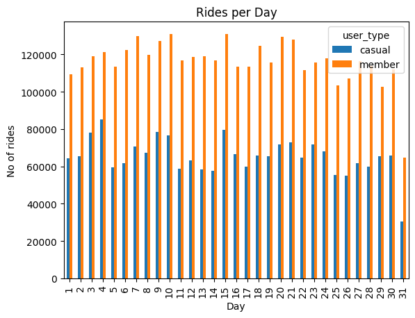

```python
rides_per_day.plot(kind='bar')
plt.title('Rides per Day')
plt.xlabel('Day')
plt.ylabel('No of rides')
```

```python
all_months_data.head()
```

|  | ride_id | rideable_type | started_at | ended_at | start_lat | start_lng | end_lat | end_lng | user_type | ride_len | ride_len_min | started_at_day | started_at_month | started_at_hour | started_at_dayname |
| --- | --- | --- | --- | --- | --- | --- | --- | --- | --- | --- | --- | --- | --- | --- | --- |
| 0 | F96D5A74A3E41399 | electric_bike | 2023-01-21 20:05:42 | 2023-01-21 20:16:33 | 41.924074 | -87.646278 | 41.930000 | -87.640000 | member | 0 days 00:10:51 | 11 | 21 | 1 | 20 | Saturday |
| 1 | 13CB7EB698CEDB88 | classic_bike | 2023-01-10 15:37:36 | 2023-01-10 15:46:05 | 41.799568 | -87.594747 | 41.809835 | -87.599383 | member | 0 days 00:08:29 | 8 | 10 | 1 | 15 | Tuesday |
| 2 | BD88A2E670661CE5 | electric_bike | 2023-01-02 07:51:57 | 2023-01-02 08:05:11 | 42.008571 | -87.690483 | 42.039742 | -87.699413 | casual | 0 days 00:13:14 | 13 | 2 | 1 | 7 | Monday |
| 3 | C90792D034FED968 | classic_bike | 2023-01-22 10:52:58 | 2023-01-22 11:01:44 | 41.799568 | -87.594747 | 41.809835 | -87.599383 | member | 0 days 00:08:46 | 9 | 22 | 1 | 10 | Sunday |
| 4 | 3397017529188E8A | classic_bike | 2023-01-12 13:58:01 | 2023-01-12 14:13:20 | 41.799568 | -87.594747 | 41.809835 | -87.599383 | member | 0 days 00:15:19 | 15 | 12 | 1 | 13 | Thursday |

### **No. of rides taken by casual and members per hour in day.**

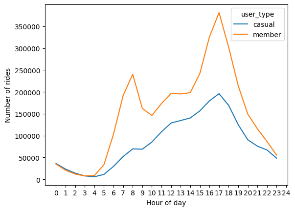

```python
plt.figure(figsize=(12,6))
ride_per_hour = all_months_data.groupby(['started_at_hour','user_type']).count()['ride_id'].reset_index().pivot(index='started_at_hour',columns='user_type',values='ride_id')
ride_per_hour.plot(kind='line')
plt.xlabel('Hour of day')
plt.xticks(np.arange(0,25))
plt.ylabel('Number of rides')
plt.show()
```

```python
all_months_data.head()
```

|  | ride_id | rideable_type | started_at | ended_at | start_lat | start_lng | end_lat | end_lng | user_type | ride_len | ride_len_min | started_at_day | started_at_month | started_at_hour | started_at_dayname |
| --- | --- | --- | --- | --- | --- | --- | --- | --- | --- | --- | --- | --- | --- | --- | --- |
| 0 | F96D5A74A3E41399 | electric_bike | 2023-01-21 20:05:42 | 2023-01-21 20:16:33 | 41.924074 | -87.646278 | 41.930000 | -87.640000 | member | 0 days 00:10:51 | 11 | 21 | 1 | 20 | Saturday |
| 1 | 13CB7EB698CEDB88 | classic_bike | 2023-01-10 15:37:36 | 2023-01-10 15:46:05 | 41.799568 | -87.594747 | 41.809835 | -87.599383 | member | 0 days 00:08:29 | 8 | 10 | 1 | 15 | Tuesday |
| 2 | BD88A2E670661CE5 | electric_bike | 2023-01-02 07:51:57 | 2023-01-02 08:05:11 | 42.008571 | -87.690483 | 42.039742 | -87.699413 | casual | 0 days 00:13:14 | 13 | 2 | 1 | 7 | Monday |
| 3 | C90792D034FED968 | classic_bike | 2023-01-22 10:52:58 | 2023-01-22 11:01:44 | 41.799568 | -87.594747 | 41.809835 | -87.599383 | member | 0 days 00:08:46 | 9 | 22 | 1 | 10 | Sunday |
| 4 | 3397017529188E8A | classic_bike | 2023-01-12 13:58:01 | 2023-01-12 14:13:20 | 41.799568 | -87.594747 | 41.809835 | -87.599383 | member | 0 days 00:15:19 | 15 | 12 | 1 | 13 | Thursday |

```python
new_df = all_months_data[all_months_data['user_type'] == 'member']
m_mean = round(new_df['ride_len_min'].mean())
```

```python
new_df_2 = all_months_data[all_months_data['user_type'] == 'casual']
c_mean = round(new_df_2['ride_len_min'].mean())
```

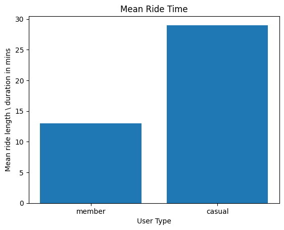

```python
plt.bar(['member','casual'], [m_mean, c_mean])
plt.title('Mean Ride Time')
plt.xlabel('User Type')
plt.ylabel('Mean ride length \ duration in mins')
plt.show()
```

```python
# ex_df = all_months_data.sample(100000)
# ex_df.to_csv('sample_d_t.csv')
```